# TS Zillow Team Project (VAR CV model)

Oleksiy Anokhin

10/29/2020

### Intro

#### Packages

```r
# Install packages
library(tidyverse) # for general analysis
library(fpp)
# library(fpp2)
library(fpp3) # for predictions
# Important notice: the latest package here is fpp3, but it does not work well sometimes with 'ts' data.
# https://stackoverflow.com/questions/64348121/error-objects-of-type-ts-not-supported-by-autoplot-cannot-knit-rmarkdown-pack
# For example, I cannot use 'autoplot()' function for such data
# Hence, I will use fpp2 for this assignment
library(ggthemes) # for beautiful themes
# library(tinytex) # for pdf documents
# library(highcharter) # for beautiful charts
library(TSA) # for TS analysis
# library(readxl) # for xls files
library(kableExtra) # for beautiful tables
library(lubridate) # for time data
library(tsibble) # for tsiblle data format
# library(plotly) # for interactive charts
library(caret) # for modeling
library(prophet) # for TS analysis
library(lubridate)
library(zoo)
library(vars)
library(stats)
# library(forecast)
library(urca)
library(stats)

# Set a theme
theme_set(theme_minimal())

# Remove scientific notations for prices
options(scipen = 999)
```

#### Import data

This dataset was aggregated from two different datasets - Median Sale Price in Chicago (Zillow) and &P/Case-Shiller IL-Chicago Home Price Index in Chicago area.

```r
# Read data
chicago_data <- read_csv("VAR data.csv")

# Print
head(chicago_data)
```

```
## # A tibble: 6 x 4
##   Date      Median_price Average_rate Home_price_index
##   <chr>            <dbl>        <dbl>            <dbl>
## 1 2/29/2008       250000         5.92             150.
## 2 3/31/2008       246000         5.97             150.
## 3 4/30/2008       249000         5.92             150.
## 4 5/31/2008       250000         6.04             150.
## 5 6/30/2008       255000         6.32             150.
## 6 7/31/2008       258500         6.43             149.
```

#### EDA

```r
# Split data into train and test
Median_price_ts <- ts(chicago_data$Median_price, start = c(2008, 2), frequency = 12)

# Print
Median_price_ts
```

```
##         Jan    Feb    Mar    Apr    May    Jun    Jul    Aug    Sep    Oct
## 2008        250000 246000 249000 250000 255000 258500 255000 245000 235000
## 2009 215000 205000 215000 215000 218000 225000 220300 220000 211000 202000
## 2010 196000 187000 200000 201000 207500 220000 210000 216600 200000 199700
## 2011 180000 178000 171500 185000 184000 195000 200000 195000 175000 170000
## 2012 153000 150000 165000 175000 180500 198000 195000 186000 177000 162000
## 2013 153000 149000 164000 179000 192000 213750 213000 208500 197500 185400
## 2014 175000 167000 183000 192500 207500 225000 220000 222500 206000 192500
## 2015 182000 179000 199000 212000 220000 228500 224900 218000 210000 203000
## 2016 190000 185995 206250 223000 227750 232000 230000 223000 210000 210000
## 2017 205500 204000 222500 235000 235000 245000 240000 229700 222000 218000
## 2018 215000 217500 230000 239000 240000 249900 243000 233000 229000 222000
## 2019 216000 222000 232500 240000 246000 249500 249000 242000 235000 231000
## 2020 223000 225000 248000 260000 251000 254000 262000 270000
##         Nov    Dec
## 2008 225000 226000
## 2009 200000 200000
## 2010 190000 190750
## 2011 163000 160000
## 2012 166000 165000
## 2013 182000 180000
## 2014 190000 190000
## 2015 198000 199000
## 2016 207500 208000
## 2017 215000 219875
## 2018 223000 220000
## 2019 231250 230000
## 2020
```

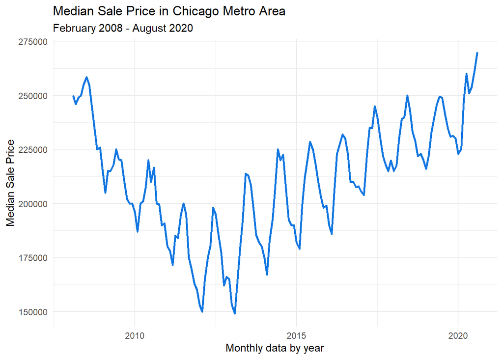

```r
# Plot
autoplot(Median_price_ts, color = "#1277e1", size = 1) +
         labs(title = "Median Sale Price in Chicago Metro Area", subtitle = "February 2008 - August 2020") +
         xlab("Monthly data by year") + ylab("Median Sale Price")
```

What can we see here?

- Decreasing and increasing trends
- Strong seasonality
- Data fluctuation changes in magnitude

```r
# Split data into train and test
Index_ts <- ts(chicago_data$Home_price_index, start = c(2008, 2), frequency = 12)

# Print
Index_ts
```

```
##           Jan      Feb      Mar      Apr      May      Jun      Jul      Aug
## 2008          150.3338 150.4275 149.9365 150.1078 149.5496 149.4617 147.8337
## 2009 126.3786 122.5037 122.3675 123.7301 124.9885 128.3207 130.5491 132.1260
## 2010 122.5663 119.7117 120.4320 121.9027 124.8982 126.1662 126.7009 124.7590
## 2011 113.2558 110.5701 110.1221 112.0091 115.6065 117.7786 119.4029 118.4741
## 2012 105.2589 102.7457 103.9762 108.6248 113.5554 116.6148 117.4470 116.6894
## 2013 110.6977 110.7256 113.8329 117.9164 121.7433 125.6946 127.6980 128.0335
## 2014 122.6117 123.6477 126.0702 127.9504 129.9236 130.9759 131.6203 130.9488
## 2015 126.4225 127.5778 128.9221 130.4190 131.8110 132.7087 132.8407 132.1746
## 2016 128.6397 130.3125 132.5194 134.6278 135.8281 136.7024 136.5434 136.1034
## 2017 135.0269 136.2389 137.6262 138.9959 140.0814 140.9132 141.1792 140.8913
## 2018 138.6099 140.0178 141.4313 142.7787 143.7022 144.2038 144.7883 144.8638
## 2019 141.5329 142.3104 143.9710 145.0744 146.2209 146.6270 146.7147 145.4738
## 2020 142.3422 144.2812 145.8514 146.9227 147.0802 148.5125 150.4549 152.2856
##           Sep      Oct      Nov      Dec
## 2008 145.4827 141.3931 137.1589 130.8476
## 2009 130.7501 129.3607 127.2558 125.1148
## 2010 122.2779 119.5701 117.8624 115.7838
## 2011 116.3912 112.4432 110.1632 107.9875
## 2012 114.8838 113.3583 112.6081 111.6511
## 2013 127.4229 125.8736 125.2906 123.7348
## 2014 129.6044 127.8857 126.7899 126.5777
## 2015 131.1087 130.2626 129.6517 129.0169
## 2016 134.8593 134.6577 135.0411 135.2008
## 2017 139.9563 139.2346 138.4524 138.5130
## 2018 144.3997 143.4795 142.4239 141.5792
## 2019 144.7253 143.6352 143.3621 142.0028
## 2020
```

[figure not shown]

```r
# Plot
autoplot(Index_ts, color = "#1277e1", size = 1) +
         labs(title = "S&P/Case-Shiller IL-Chicago Home Price Index", subtitle = "February 2008 - August 2020") +
         xlab("Monthly data by year") + ylab("Average rate")
```

#### Split into train and test data

```r
# Split train and test data for Median price
Median_price_ts_train <- window(Median_price_ts, end = c(2018, 12), frequency = 12)
Median_price_ts_test <- window(Median_price_ts, start = c(2019,1), end = c(2019,12), frequency = 12)

# Split train and test data for Index
Index_ts_train <- ts(Index_ts, start = c(2008, 2), end = c(2014, 12), frequency = 12)
Index_ts_test <- ts(Index_ts, start = c(2015, 1), end = c(2016, 12), frequency = 12)
```

```r
# Create a window
train_end <- c(2018, 12)
test_start <- c(2019, 1)
test_end <- c(2019, 12)
```

```r
# Define again train and test
Median_price_ts_train <- window(Median_price_ts, end = train_end)
Median_price_ts_test <- window(Median_price_ts, start = test_start, end = test_end)
```

```r
# Define again train and test
Index_ts_train <- window(Index_ts, end = train_end)
Index_ts_test <- window(Index_ts, start = test_start, end = test_end)
```

```r
# Check correlation
cor(Median_price_ts, Index_ts)
```

```
## [1] 0.9159594
```

```r
# Check correlation for train data
cor(Median_price_ts_train, Index_ts_train)
```

```
## [1] 0.90007
```

We can see that correlation is very high and very positive.

### VAR model

#### Stationarity

First, we need to check if our data is stationary.

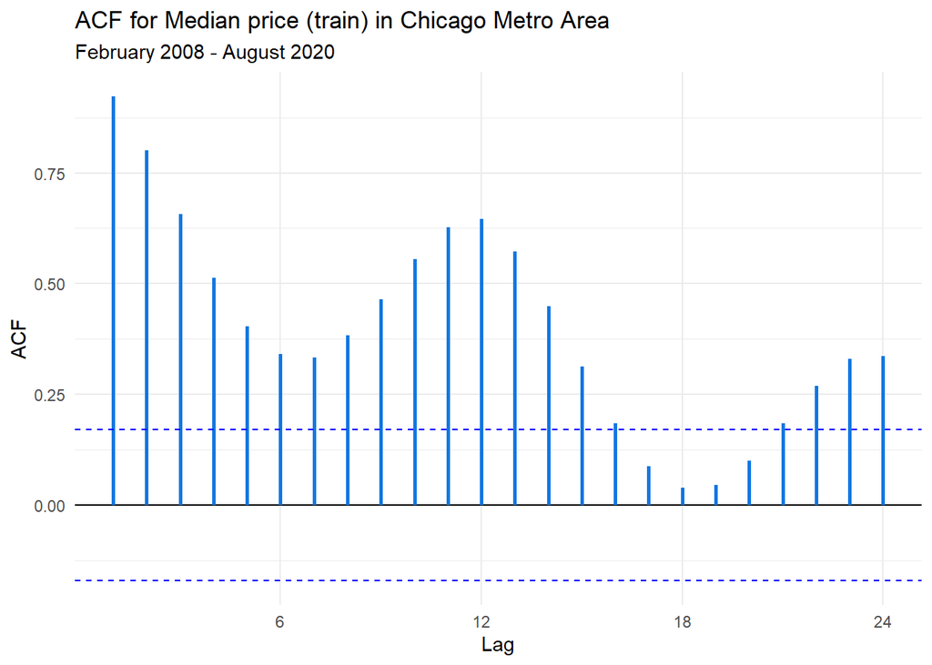

```r
# Check autocorrelation for Median price (train data)
ggAcf(Median_price_ts_train, color = "#1277e1", size = 1) +
         labs(title = "ACF for Median price (train) in Chicago Metro Area", subtitle = "February 2008 - August 2020")
```

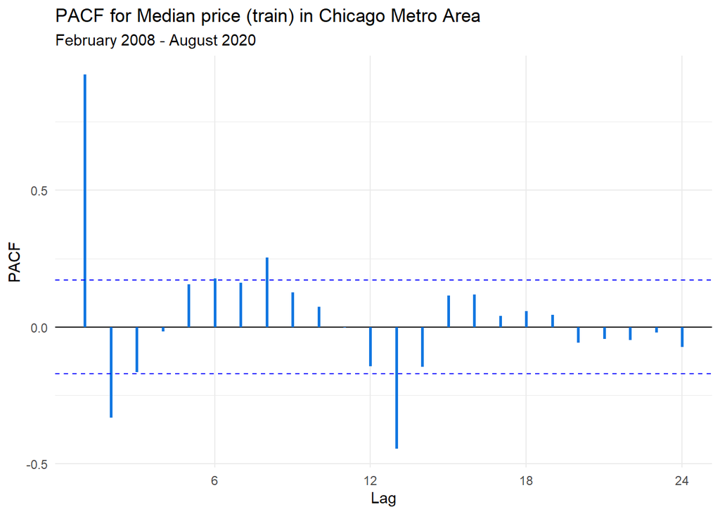

```r
# Check partial autocorrelation for Median price (train data)
ggPacf(Median_price_ts_train, color = "#1277e1", size = 1) +
         labs(title = "PACF for Median price (train) in Chicago Metro Area", subtitle = "February 2008 - August 2020")
```

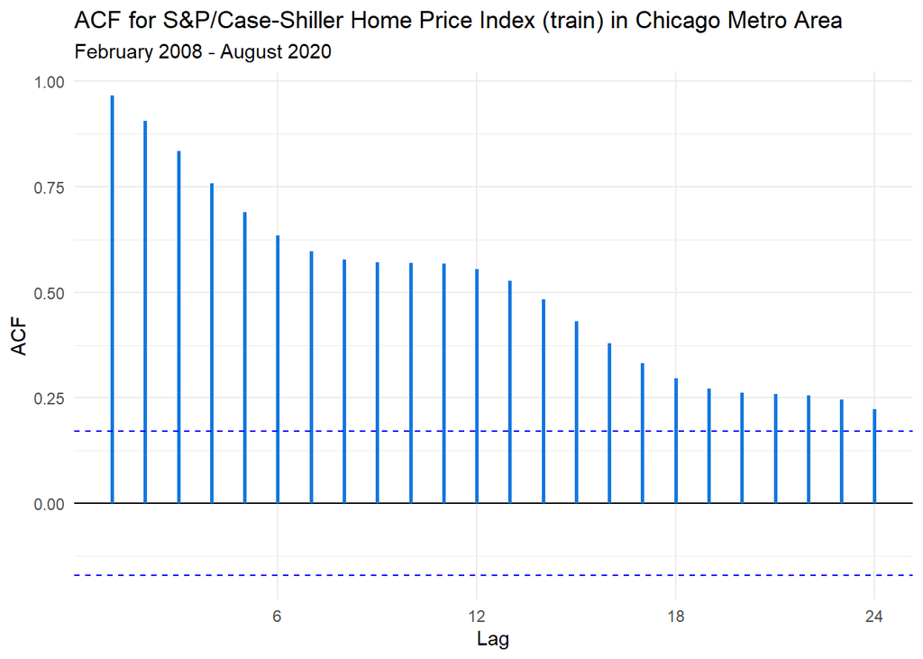

```r
# Check autocorrelation for Index (train data)
ggAcf(Index_ts_train, color = "#1277e1", size = 1) +
         labs(title = "ACF for S&P/Case-Shiller Home Price Index (train) in Chicago Metro Area", subtitle = "February 2008 - August 2020")
```

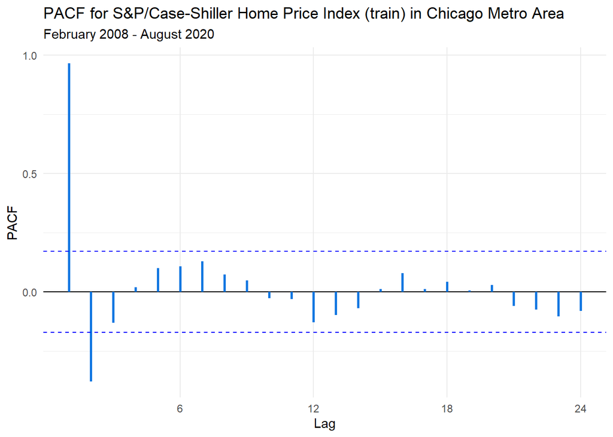

```r
# Check partial autocorrelation for Index (train data)
ggPacf(Index_ts_train, color = "#1277e1", size = 1) +
         labs(title = "PACF for S&P/Case-Shiller Home Price Index (train) in Chicago Metro Area", subtitle = "February 2008 - August 2020")
```

As we can see, we have a strong autocorrelation in both cases.

#### Tests

However, let’s check it formally with tests.

This is a slide from our Time Series class with Professor Abado as a reference.

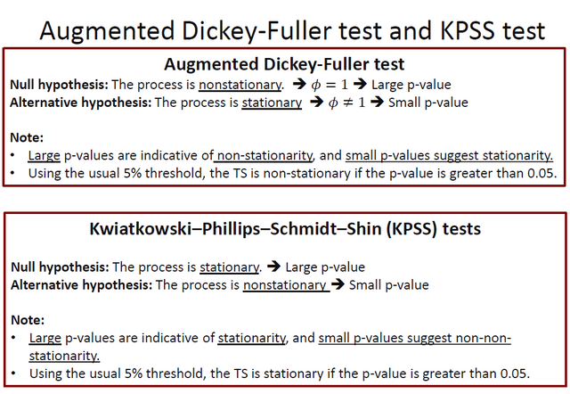

```r
# Run KPSS test for Median price train data
kpss.test(Median_price_ts_train)
```

```
##
##  KPSS Test for Level Stationarity
##
## data:  Median_price_ts_train
## KPSS Level = 0.55799, Truncation lag parameter = 4, p-value = 0.02861
```

```r
# Run KPSS test for Average rate train data
kpss.test(Index_ts_train)
```

```
##
##  KPSS Test for Level Stationarity
##
## data:  Index_ts_train
## KPSS Level = 0.8458, Truncation lag parameter = 4, p-value = 0.01
```

```r
# Run ADF test for Average rate train data
adf.test(Median_price_ts_train)
```

```
##
##  Augmented Dickey-Fuller Test
##
## data:  Median_price_ts_train
## Dickey-Fuller = -3.0201, Lag order = 5, p-value = 0.1523
## alternative hypothesis: stationary
```

```r
# Run ADF test for Average rate train data
adf.test(Index_ts_train)
```

```
##
##  Augmented Dickey-Fuller Test
##
## data:  Index_ts_train
## Dickey-Fuller = -4.2282, Lag order = 5, p-value = 0.01
## alternative hypothesis: stationary
```

As we can see, both tests for both variables tell us that the process is not stationary. However, ADF test for Index data tells us the opposite.

### VAR with Diff1

**Important:** Here and in all other steps I replicate the first result, so there is a lot of repetition here, which is still important.

#### 1st order differencing

First, we need to difference data (1st order).

```r
# Create new variables
Median_price_ts_diff1 <- diff(diff(Median_price_ts, differences = 1), lag = 12, differences = 1)
Index_ts_diff1 <- diff(diff(Index_ts, differences = 1), lag = 12, differences = 1)

# Check class
class(Median_price_ts_diff1)
```

```
## [1] "ts"
```

```r
class(Index_ts_diff1)
```

```
## [1] "ts"
```

```r
# Print
Median_price_ts_diff1
```

```
##         Jan    Feb    Mar    Apr    May    Jun    Jul    Aug    Sep    Oct
## 2009                14000  -3000   2000   2000  -8200   3200   1000   1000
## 2010   7000   1000   3000   1000   3500   5500  -5300   6900  -7600   8700
## 2011  -6750   7000 -19500  12500  -7500  -1500  15000 -11600  -3400  -4700
## 2012   3750  -1000  21500  -3500   6500   6500  -8000  -4000  11000 -10000
## 2013  -5000  -1000      0   5000   7500   4250   2250   4500  -2000   2900
## 2014   7000  -4000   1000  -5500   2000  -4250  -4250   7000  -5500  -1400
## 2015  -3000   5000   4000   3500  -7000  -9000   1400  -9400   8500   6500
## 2016  -1000  -1005    255   3750  -3250  -4250   1600   -100  -5000   7000
## 2017   6500   2505  -1755  -4250  -4750   5750  -3000  -3300   5300  -4000
## 2018  -2375   4000  -6000  -3500   1000   -100  -1900    300   3700  -3000
## 2019    875   3500  -2000  -1500   5000  -6400   6400   3000  -3000   3000
## 2020  -3000  -4000  12500   4500 -15000   -500   8500  15000
##         Nov    Dec
## 2009   8000  -1000
## 2010  -7700    750
## 2011   2700  -3750
## 2012  11000   2000
## 2013  -7400  -1000
## 2014    900   2000
## 2015  -2500   1000
## 2016   2500   -500
## 2017   -500   4375
## 2018   4000  -7875
## 2019   -750   1750
## 2020
```

```r
Index_ts_diff1
```

```
##             Jan        Feb        Mar        Apr        May        Jun
## 2009                       -0.2299200  1.8536600  1.0870700  3.8904700
## 2010  1.9204500  1.0203100  0.8565900  0.1080700  1.7371100 -2.0642800
## 2011  0.0205100  0.1689200 -1.1683700  0.4162200  0.6019900  0.9041000
## 2012 -0.2005500  0.1724700  1.6785500  2.7616100  1.3331800  0.8872800
## 2013  1.7752100  2.5410400  1.8768300 -0.5651400 -1.1036600  0.8919200
## 2014 -0.1696900  1.0081796 -0.6848424 -2.2032852 -1.8537913 -2.8989145
## 2015  0.9678508  0.1193181 -1.0781504 -0.3833170 -0.5811764 -0.1546103
## 2016 -0.2219566  0.5174702  0.8624732  0.6115726 -0.1916782 -0.0234103
## 2017  0.2032362 -0.4608479 -0.8194593 -0.7387400 -0.1147949 -0.0425918
## 2018  0.2708180  0.1958677  0.0261379 -0.0222329 -0.1620081 -0.3301484
## 2019 -0.1432387 -0.6302832  0.2470839 -0.2440129  0.2230260 -0.0955250
## 2020  0.3856915  1.1614405 -0.0903741 -0.0321131 -0.9890518  1.0262374
##             Jul        Aug        Sep        Oct        Nov        Dec
## 2009  2.3162400  3.2048900  0.9751700  2.7001400  2.1293400  4.1702300
## 2010 -1.6936000 -3.5188800 -1.1052300 -1.3183200  0.3971500  0.0624600
## 2011  1.0895300  1.0131900  0.3982300 -1.2403000 -0.5722600 -0.0970800
## 2012 -0.7921000  0.1711300  0.2773400  2.4224900  1.5298900  1.2186100
## 2013  1.1712000  1.0931500  1.1949000 -0.0237300  0.1671700 -0.5988200
## 2014 -1.3590469 -1.0070017 -0.7337168 -0.1695151 -0.5127624  1.3436072
## 2015 -0.5123975  0.0054258  0.2784611  0.8726281  0.4848566 -0.4225533
## 2016 -0.2909513  0.2260087 -0.1781284  0.6445394  0.9942617  0.7944988
## 2017  0.4250552  0.1521672  0.3090241 -0.5201586 -1.1655122 -0.0990867
## 2018  0.3184236  0.3634094  0.4708654 -0.1983794 -0.2734965 -0.9053103
## 2019 -0.4967482 -1.3164725 -0.2843384 -0.1700338  0.7825778 -0.5145562
## 2020  1.8546745  3.0716383
```

```r
# Define again train and test for Median price
Median_price_ts_train_diff1 <- window(Median_price_ts_diff1, end = train_end)
Median_price_ts_test_diff1 <- window(Median_price_ts_diff1, start = test_start, end = test_end)
```

```r
# Define again train and test for Index
Index_ts_train_diff1 <- window(Index_ts_diff1, end = train_end)
Index_ts_test_diff1 <- window(Index_ts_diff1, start = test_start, end = test_end)
```

```r
# Check correlation between differenced variables
cor(Median_price_ts_train_diff1, Index_ts_train_diff1)
```

```
## [1] 0.1123419
```

We can see that our correlation dropped significantly after differencing - from `0.9` to `0.1`.

#### Stationarity

Now we need to check the stationarity again.

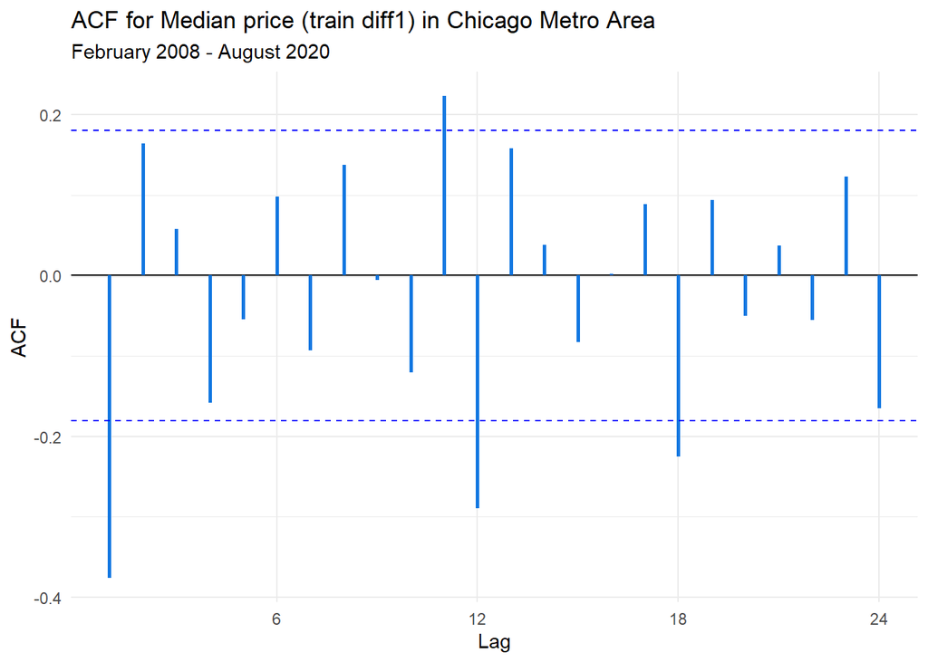

```r
# Check autocorrelation
ggAcf(Median_price_ts_train_diff1, color = "#1277e1", size = 1) +
         labs(title = "ACF for Median price (train diff1) in Chicago Metro Area", subtitle = "February 2008 - August 2020")
```

Here we have spikes at lags 1, 11, 12, 18.

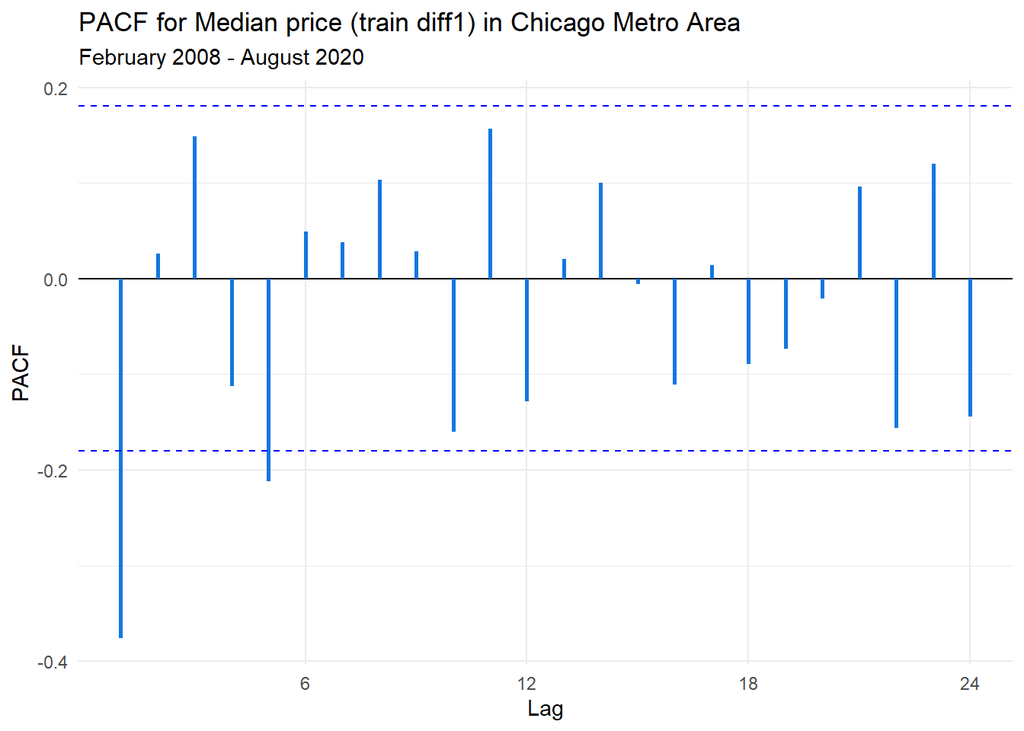

```r
# Check partial autocorrelation
ggPacf(Median_price_ts_train_diff1, color = "#1277e1", size = 1) +
         labs(title = "PACF for Median price (train diff1) in Chicago Metro Area", subtitle = "February 2008 - August 2020")
```

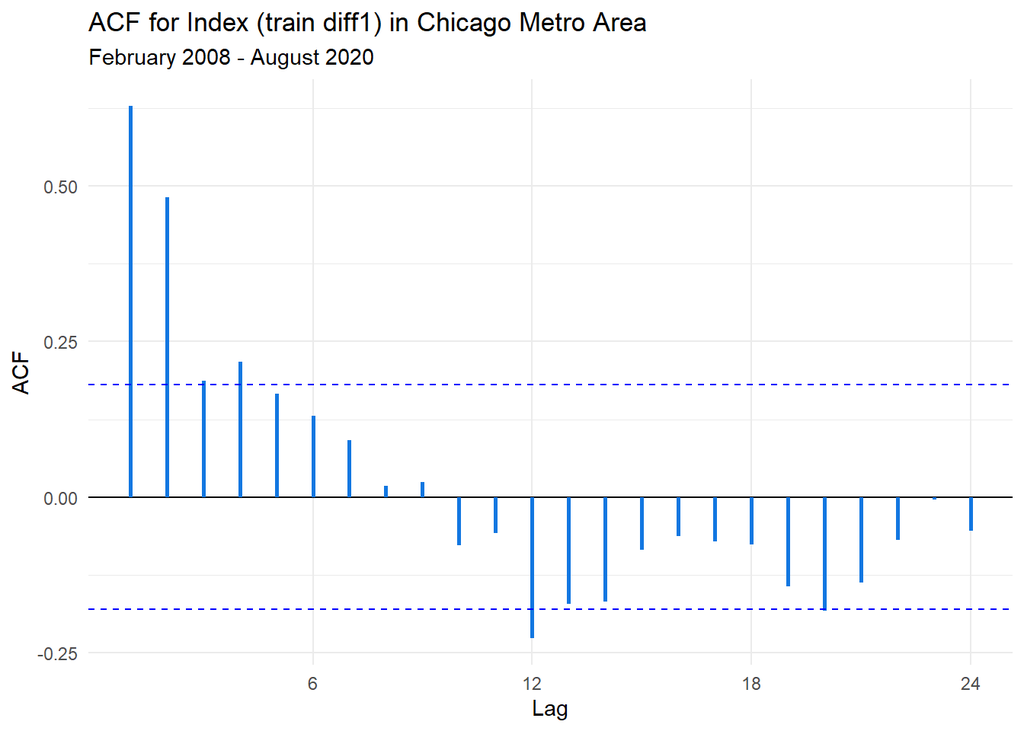

```r
# Check autocorrelation
ggAcf(Index_ts_train_diff1, color = "#1277e1", size = 1) +
         labs(title = "ACF for Index (train diff1) in Chicago Metro Area", subtitle = "February 2008 - August 2020")
```

Here we have spikes at lags 1-4 and 12.

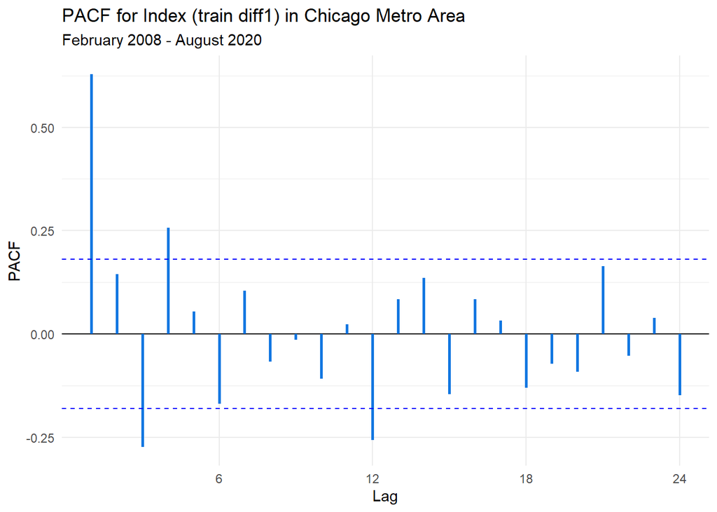

```r
# Check partial autocorrelation
ggPacf(Index_ts_train_diff1, color = "#1277e1", size = 1) +
         labs(title = "PACF for Index (train diff1) in Chicago Metro Area", subtitle = "February 2008 - August 2020")
```

#### Tests

```r
kpss.test(Median_price_ts_train_diff1)
```

```
##
##  KPSS Test for Level Stationarity
##
## data:  Median_price_ts_train_diff1
## KPSS Level = 0.23969, Truncation lag parameter = 4, p-value = 0.1
```

```r
kpss.test(Index_ts_train_diff1)
```

```
##
##  KPSS Test for Level Stationarity
##
## data:  Index_ts_train_diff1
## KPSS Level = 0.40504, Truncation lag parameter = 4, p-value = 0.07498
```

```r
adf.test(Median_price_ts_train_diff1)
```

```
##
##  Augmented Dickey-Fuller Test
##
## data:  Median_price_ts_train_diff1
## Dickey-Fuller = -6.2291, Lag order = 4, p-value = 0.01
## alternative hypothesis: stationary
```

```r
adf.test(Index_ts_train_diff1)
```

```
##
##  Augmented Dickey-Fuller Test
##
## data:  Index_ts_train_diff1
## Dickey-Fuller = -3.3897, Lag order = 4, p-value = 0.05967
## alternative hypothesis: stationary
```

As we can see, we have some controversial results here.

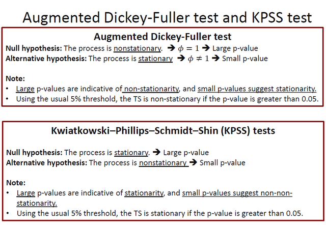

In our case we for Median price we have large p-values for both variables in a KPSS test. In ADF for Median price p-value is small (which is good), but it is high for Index variable. However, the p-value is only around 0.06, which can be considered acceptable.

#### VAR select

```r
# Use VAR select
model1_diff1 <- VARselect(cbind(Median_price_ts_train_diff1, Index_ts_train_diff1))

# Print the model
model1_diff1
```

```
## $selection
## AIC(n)  HQ(n)  SC(n) FPE(n)
##      6      1      1      6
##
## $criteria
##                     1              2              3              4
## AIC(n)       16.86534       16.93422       16.89282       16.90292
## HQ(n)        16.92575       17.03492       17.03380       17.08417
## SC(n)        17.01434       17.18257       17.24051       17.34994
## FPE(n) 21112296.46658 22620176.55280 21707943.50335 21937242.23486
##                     5              6              7              8
## AIC(n)       16.86201       16.82403       16.84615       16.90744
## HQ(n)        17.08353       17.08583       17.14824       17.24981
## SC(n)        17.40837       17.46973       17.59119       17.75182
## FPE(n) 21071309.56450 20304903.81344 20785524.70877 22136174.93740
##                     9             10
## AIC(n)       16.95912       16.92883
## HQ(n)        17.34176       17.35175
## SC(n)        17.90284       17.97188
## FPE(n) 23359645.85043 22722420.32833
```

`VARselect` offers us to try model with p = 6.

#### VAR(6) Model

```r
# Var 8
varmodel6 <- VAR(cbind(Median_price_ts_train_diff1, Index_ts_train_diff1), p = 6, type = "both", season = 12)

# Pormonteau test
serial.test(varmodel6, lags.pt = 20, type = "PT.asymptotic")
```

```
##
##  Portmanteau Test (asymptotic)
##
## data:  Residuals of VAR object varmodel6
## Chi-squared = 76.339, df = 56, p-value = 0.03672
```

```r
# Print
summary(varmodel6)
```

```
##
## VAR Estimation Results:
## =========================
## Endogenous variables: Median_price_ts_train_diff1, Index_ts_train_diff1
## Deterministic variables: both
## Sample size: 112
## Log Likelihood: -1231.188
## Roots of the characteristic polynomial:
## 0.817 0.817 0.8155 0.8155 0.7984 0.7984 0.7681 0.7681 0.7538 0.7538 0.7264 0.1959
## Call:
## VAR(y = cbind(Median_price_ts_train_diff1, Index_ts_train_diff1),
##     p = 6, type = "both", season = 12L)
##
##
## Estimation results for equation Median_price_ts_train_diff1:
## ============================================================
## Median_price_ts_train_diff1 = Median_price_ts_train_diff1.l1 + Index_ts_train_diff1.l1 + Median_price_ts_train_diff1.l2 + Index_ts_train_diff1.l2 + Median_price_ts_train_diff1.l3 + Index_ts_train_diff1.l3 + Median_price_ts_train_diff1.l4 + Index_ts_train_diff1.l4 + Median_price_ts_train_diff1.l5 …
##
##                                   Estimate  Std. Error t value Pr(>|t|)
## Median_price_ts_train_diff1.l1    -0.41567     0.10765  -3.861 0.000216 ***
## Index_ts_train_diff1.l1          405.94719   650.25505   0.624 0.534071
## Median_price_ts_train_diff1.l2     0.04442     0.10936   0.406 0.685588
## Index_ts_train_diff1.l2         -547.15094   756.44235  -0.723 0.471423
## Median_price_ts_train_diff1.l3     0.04731     0.10596   0.447 0.656341
## Index_ts_train_diff1.l3         1755.18523   722.49563   2.429 0.017183 *
## Median_price_ts_train_diff1.l4    -0.25391     0.10794  -2.352 0.020913 *
## Index_ts_train_diff1.l4        -1507.26936   719.11498  -2.096 0.038986 *
## Median_price_ts_train_diff1.l5    -0.26361     0.11046  -2.386 0.019183 *
## Index_ts_train_diff1.l5          497.44346   747.64861   0.665 0.507591
## Median_price_ts_train_diff1.l6     0.01247     0.10043   0.124 0.901444
## Index_ts_train_diff1.l6         1184.15713   619.80219   1.911 0.059357 .
## const                            646.87631  1246.75163   0.519 0.605183
## trend                             -8.33055    16.97541  -0.491 0.624844
## sd1                            -1494.33227  2524.48255  -0.592 0.555429
## sd2                             -541.24115  2521.22033  -0.215 0.830524
## sd3                            -2239.61138  2553.95686  -0.877 0.382946
## sd4                            -1441.31049  2555.75706  -0.564 0.574241
## sd5                            -1880.55373  2565.44286  -0.733 0.465509
## sd6                            -3318.84365  2588.42886  -1.282 0.203184
## sd7                            -1533.52377  2470.24852  -0.621 0.536356
```

[output cut: 73 more lines]

```
## Residual standard error: 0.8701 on 87 degrees of freedom
## Multiple R-Squared: 0.546,   Adjusted R-squared: 0.4208
## F-statistic:  4.36 on 24 and 87 DF,  p-value: 0.0000002075
##
##
##
## Covariance matrix of residuals:
##                             Median_price_ts_train_diff1 Index_ts_train_diff1
## Median_price_ts_train_diff1                    28126097             1103.346
## Index_ts_train_diff1                               1103                0.757
##
## Correlation matrix of residuals:
##                             Median_price_ts_train_diff1 Index_ts_train_diff1
## Median_price_ts_train_diff1                      1.0000               0.2391
## Index_ts_train_diff1                             0.2391               1.0000
```

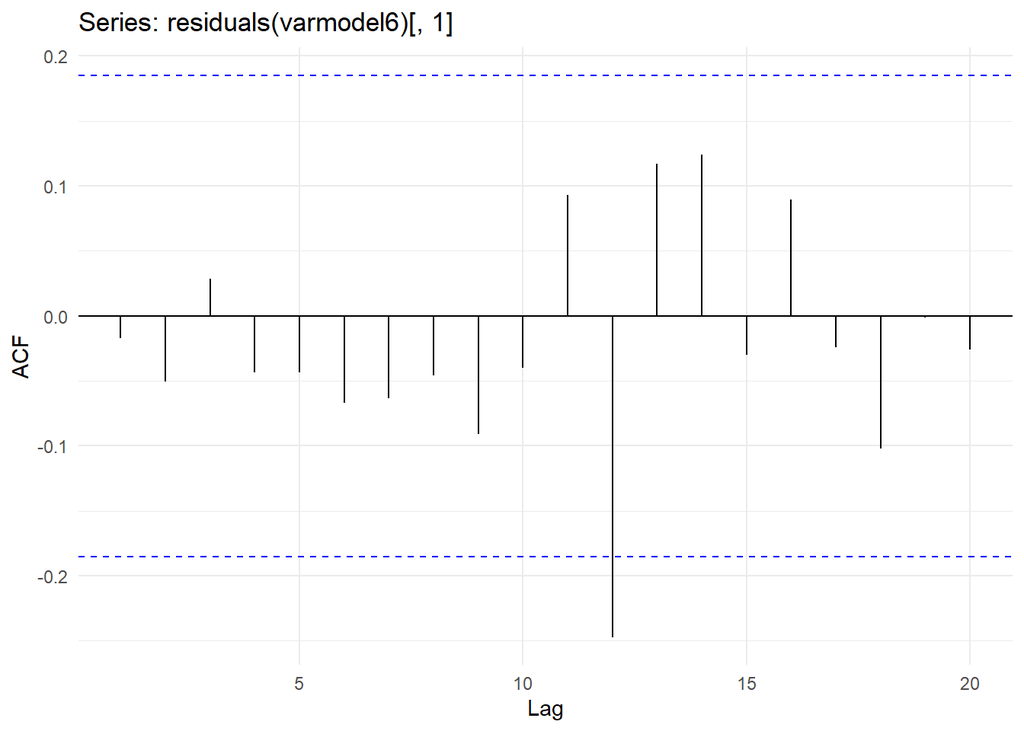

```r
# Check residuals for the model
ggAcf(residuals(varmodel6)[, 1])
```

#### Forecast

```r
# Create a forecast
varmodel6_forecast <- ts(predict(varmodel6, n.ahead = 12, ci = .95)$fcst$Median_price_ts_train[, 1], start = test_start, frequency = 12)
```

#### Evaluate the model

```r
# Analyze accuracy
accuracy(varmodel6_forecast, Median_price_ts_test_diff1)
```

```
##                ME     RMSE      MAE      MPE     MAPE       ACF1 Theil's U
## Test set 1278.139 4061.737 3305.597 103.2291 107.5575 -0.5230008 0.8973684
```

```r
accuracy(varmodel6_forecast, Index_ts_test_diff1)
```

```
##                ME    RMSE      MAE      MPE     MAPE       ACF1 Theil's U
## Test set 455.0025 1471.54 1294.127 82205.61 493834.4 -0.1020238  2572.761
```

#### Cross-validation

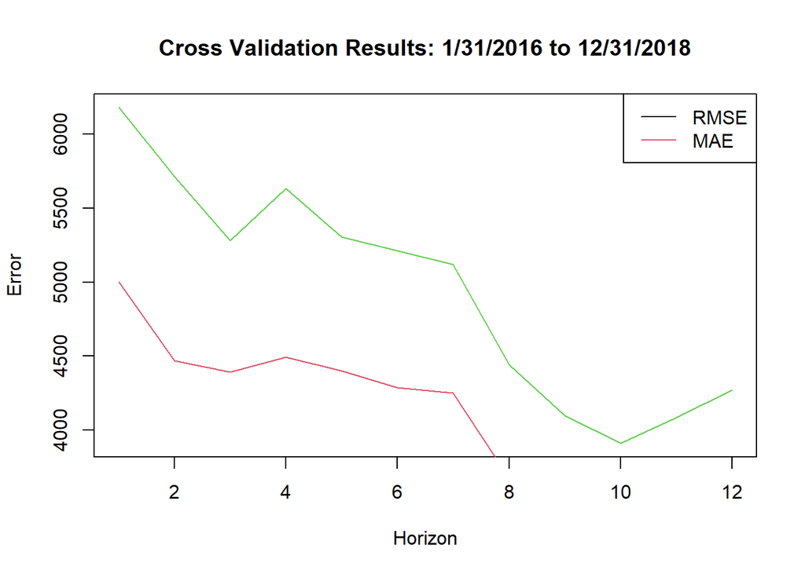

```r
# Define parameters
k <- 72 # Minimum observations (6 years)
p <- 12 # Period
st <- 2014 + 11/12
error <- matrix(NA, 36, 12)
dates <- c()
for(i in (1:36))

# Create a function
{
  train <- window(Median_price_ts_diff1, start = st + (i - k + 1)/p, end = st + i/p)
  test <- window(Median_price_ts_diff1, start = st + (i + 1)/p, end = st + (i + 12)/p)
  rate_train <- window(Index_ts_diff1, start = st + (i - k + 1)/p, end = st + i/p)
  rate_test <- window(Index_ts_diff1, start = st + (i + 1)/p, end = st+(i + 12)/p)
  dates[i] <- st + (i + 12)/p
  var_model <-  VAR(cbind(train, rate_train), p = 8, type = "both", season = 12)

  f <- ts(predict(var_model, n.ahead = 12, ci = .95)$fcst$train[, 1], start = st + (i + 1)/p, frequency = 12)
  error[i, 1:length(test)] <- f - test
}

# Define and plot metrics
MAE <- colMeans(abs(error), na.rm = TRUE)
RMSE <- sqrt(colMeans(error**2, na.rm = TRUE))
plot(1:12, RMSE, type = "l", col = 3, xlab = "Horizon", ylab = "Error", main = 'Cross Validation Results: 1/31/2016 to 12/31/2018')
lines(1:12, MAE, type = "l", col = 2)
legend("topright", legend = c("RMSE", "MAE"), col = 1:4, lty = 1)
```

```r
# Print metrics
print(MAE)
```

```
##  [1] 5002.260 4470.045 4393.325 4494.071 4400.078 4286.366 4250.499 3673.331
##  [9] 3188.403 3103.285 3181.826 3394.574
```

```r
print(RMSE)
```

```
##  [1] 6181.003 5714.076 5282.921 5631.547 5306.842 5212.857 5118.423 4440.922
##  [9] 4098.599 3910.865 4086.670 4271.168
```

```r
print(sum(MAE)/12)
```

```
## [1] 3986.505
```

```r
print(sum(RMSE)/12)
```

```
## [1] 4937.991
```

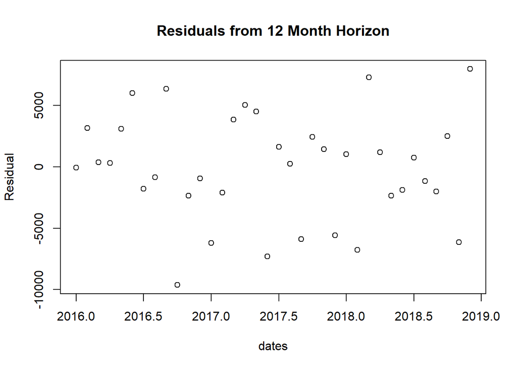

```r
# Plot residuals
plot(dates, error[, 12], ylab = 'Residual', main = 'Residuals from 12 Month Horizon')
```

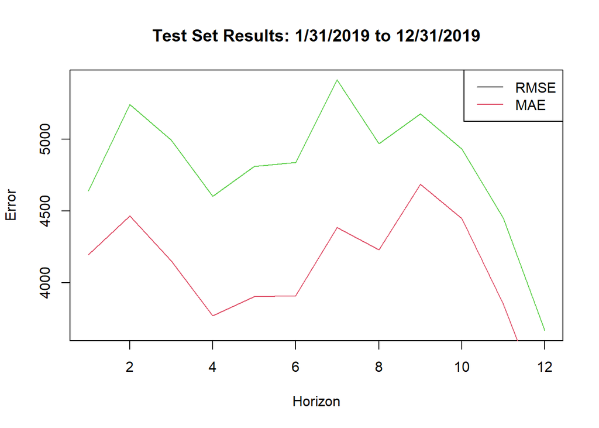

```r
error <- matrix(NA, 12, 12)
dates <- c()
for(i in (37:48))

{
  train <- window(Median_price_ts_diff1, start = st + (i - k + 1)/p, end = st + i/p)
  test <- window(Median_price_ts_diff1, start = st + (i + 1)/p, end = st + (i + 12)/p)
  rate_train <- window(Index_ts_diff1, start = st + (i - k + 1)/p, end = st + i/p)
  rate_test <- window(Index_ts_diff1, start = st + (i + 1)/p, end = st + (i + 12)/p)
  dates[i - 36] <- st + (i + 12)/p
  var_model <-  VAR(cbind(train, rate_train), p = 8, type = "both", season = 12)

  f <- ts(predict(var_model, n.ahead = 12, ci = .95)$fcst$train[, 1], start = st + (i + 1)/p, frequency = 12)
  error[i - 36, 1:length(test)] <- f - test
}

# Define metrics and plot them
MAE <- colMeans(abs(error), na.rm = TRUE)
RMSE <- sqrt(colMeans(error**2, na.rm = TRUE))
plot(1:12, RMSE, type = "l",col = 3, xlab = "Horizon", ylab = "Error", main = 'Test Set Results: 1/31/2019 to 12/31/2019')
lines(1:12, MAE, type = "l", col = 2)
legend("topright", legend = c("RMSE", "MAE"), col = 1:4, lty = 1)
```

```r
# Print metrics
print(MAE)
```

```
##  [1] 4195.347 4464.679 4152.801 3769.628 3902.594 3909.930 4384.604 4230.686
##  [9] 4686.492 4446.403 3850.829 3104.320
```

```r
print(RMSE)
```

```
##  [1] 4639.741 5244.358 4996.213 4601.996 4811.362 4839.393 5413.596 4968.889
##  [9] 5179.965 4933.115 4449.745 3665.699
```

```r
print(sum(MAE)/12)
```

```
## [1] 4091.526
```

```r
print(sum(RMSE)/12)
```

```
## [1] 4812.006
```

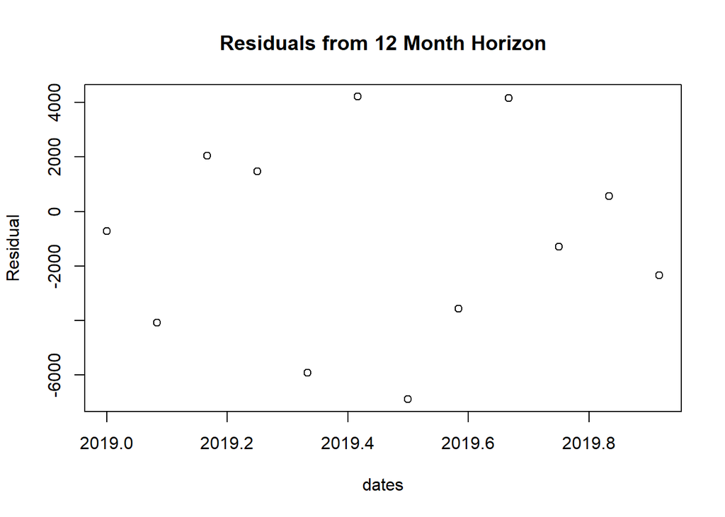

```r
# Plot residuals
plot(dates, error[, 12], ylab = 'Residual', main = 'Residuals from 12 Month Horizon')
```

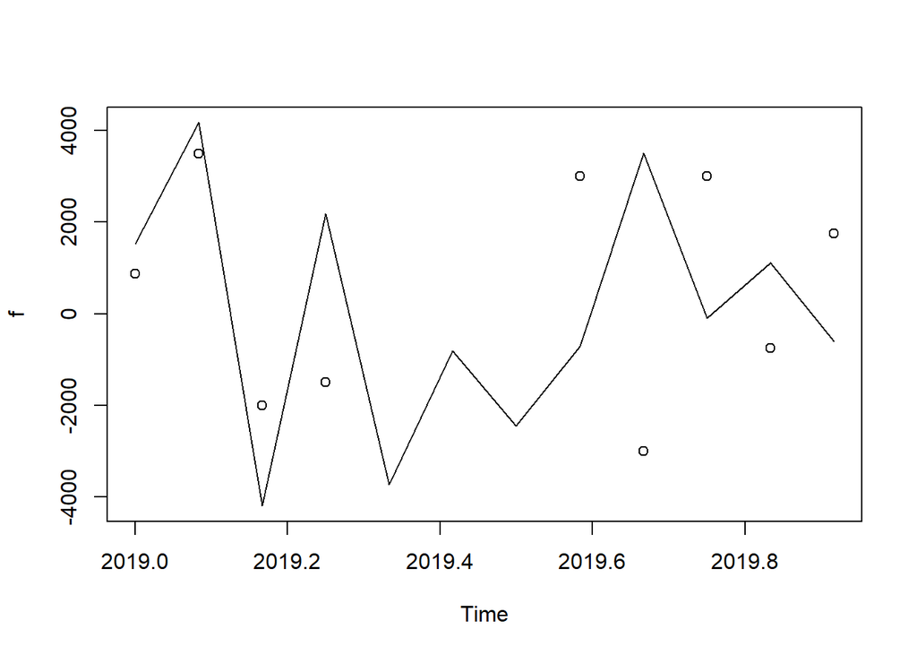

```r
# Compare results
plot(f)
points(test)
```

#### VAR(1) Model

```r
# Var 8
varmodel1 <- VAR(cbind(Median_price_ts_train_diff1, Index_ts_train_diff1), p = 1, type = "both", season = 12)

# Pormonteau test
serial.test(varmodel1, lags.pt = 20, type = "PT.asymptotic")
```

```
##
##  Portmanteau Test (asymptotic)
##
## data:  Residuals of VAR object varmodel1
## Chi-squared = 143.52, df = 76, p-value = 0.000004645
```

```r
# Print
summary(varmodel1)
```

```
##
## VAR Estimation Results:
## =========================
## Endogenous variables: Median_price_ts_train_diff1, Index_ts_train_diff1
## Deterministic variables: both
## Sample size: 117
## Log Likelihood: -1321.864
## Roots of the characteristic polynomial:
## 0.6032 0.4324
## Call:
## VAR(y = cbind(Median_price_ts_train_diff1, Index_ts_train_diff1),
##     p = 1, type = "both", season = 12L)
##
##
## Estimation results for equation Median_price_ts_train_diff1:
## ============================================================
## Median_price_ts_train_diff1 = Median_price_ts_train_diff1.l1 + Index_ts_train_diff1.l1 + const + trend + sd1 + sd2 + sd3 + sd4 + sd5 + sd6 + sd7 + sd8 + sd9 + sd10 + sd11
##
##                                   Estimate  Std. Error t value   Pr(>|t|)
## Median_price_ts_train_diff1.l1    -0.41191     0.08829  -4.665 0.00000938 ***
## Index_ts_train_diff1.l1          798.67750   449.43331   1.777     0.0785 .
## const                            891.92979  1133.19733   0.787     0.4331
## trend                            -10.76903    16.04054  -0.671     0.5035
## sd1                             -872.18741  2629.20872  -0.332     0.7408
## sd2                             -132.86921  2570.88595  -0.052     0.9589
## sd3                            -1196.02292  2566.95291  -0.466     0.6423
## sd4                             -855.64916  2570.26452  -0.333     0.7399
## sd5                            -2197.60966  2568.29492  -0.856     0.3942
## sd6                            -2396.11658  2572.84195  -0.931     0.3539
## sd7                            -1057.05736  2567.97732  -0.412     0.6815
## sd8                             -846.05119  2565.25979  -0.330     0.7422
## sd9                             -261.28375  2563.11625  -0.102     0.9190
## sd10                           -1421.72527  2563.62036  -0.555     0.5804
## sd11                            -982.34661  2629.74328  -0.374     0.7095
## ---
## Signif. codes:  0 '***' 0.001 '**' 0.01 '*' 0.05 '.' 0.1 ' ' 1
##
##
## Residual standard error: 5575 on 102 degrees of freedom
## Multiple R-Squared: 0.2047,  Adjusted R-squared: 0.09549
```

[output cut: 43 more lines]

```
## Residual standard error: 0.9777 on 102 degrees of freedom
## Multiple R-Squared: 0.4439,  Adjusted R-squared: 0.3676
## F-statistic: 5.817 on 14 and 102 DF,  p-value: 0.00000003241
##
##
##
## Covariance matrix of residuals:
##                             Median_price_ts_train_diff1 Index_ts_train_diff1
## Median_price_ts_train_diff1                  31082255.9             603.5189
## Index_ts_train_diff1                              603.5               0.9558
##
## Correlation matrix of residuals:
##                             Median_price_ts_train_diff1 Index_ts_train_diff1
## Median_price_ts_train_diff1                      1.0000               0.1107
## Index_ts_train_diff1                             0.1107               1.0000
```

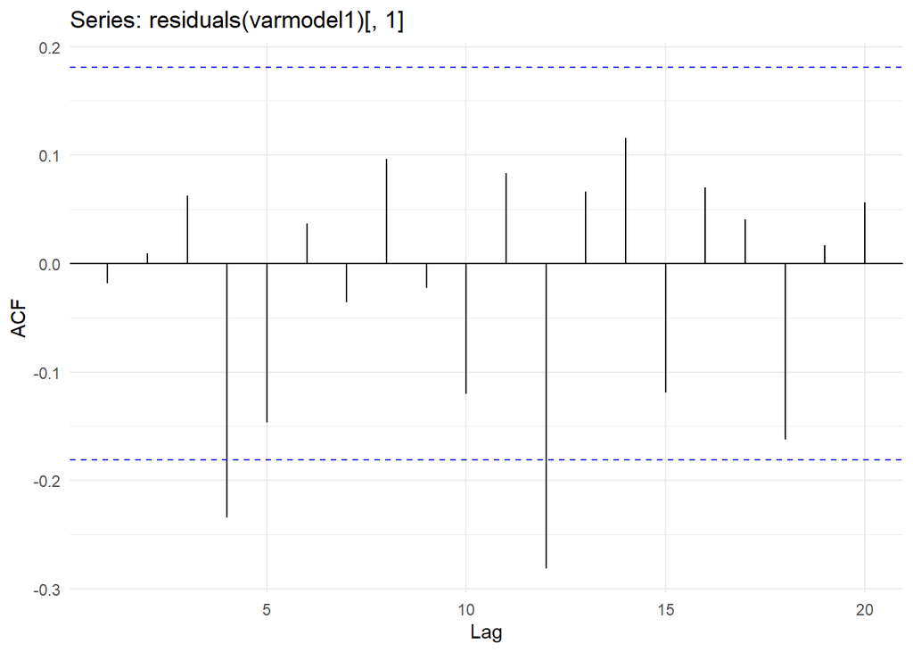

```r
# Check residuals for the model
ggAcf(residuals(varmodel1)[, 1])
```

#### Forecast

```r
# Create a forecast
varmodel1_forecast <- ts(predict(varmodel1, n.ahead = 12, ci = .95)$fcst$Median_price_ts_train[, 1], start = test_start, frequency = 12)
```

#### Evaluate the model

```r
# Analyze accuracy
accuracy(varmodel1_forecast, Median_price_ts_test_diff1)
```

```
##                ME    RMSE      MAE      MPE     MAPE       ACF1 Theil's U
## Test set 1386.083 4323.74 3705.297 97.56261 122.1731 -0.5873495  1.058247
```

```r
accuracy(varmodel1_forecast, Index_ts_test_diff1)
```

```
##                ME     RMSE      MAE     MPE     MAPE        ACF1 Theil's U
## Test set 562.9458 1178.579 945.2754 10929.8 344905.6 -0.08354874  2671.078
```

This model performs worse, so I will not do any cross-validation.

### VAR with Diff2

#### 2st order differencing

Again, we need to difference data (2st order)

```r
# Create new variables
Median_price_ts_diff2 <- diff(diff(Median_price_ts, differences = 2), lag = 12, differences = 2)
Index_ts_diff2 <- diff(diff(Index_ts, differences = 2), lag = 12, differences = 2)

# Check class
class(Median_price_ts_diff2)
```

```
## [1] "ts"
```

```r
class(Index_ts_diff2)
```

```
## [1] "ts"
```

```r
# Print
Median_price_ts_diff2
```

```
##         Jan    Feb    Mar    Apr    May    Jun    Jul    Aug    Sep    Oct
## 2010                       15000  -2500   2000   -600    800 -12300  16300
## 2011 -15500  19750 -28500  34000 -22500   4000  27300 -38800  22700 -17600
## 2012  15000 -18500  49000 -57000  30000  -6000 -31000  30600   6800 -19700
## 2013 -14500   8750 -21500  30000  -7500  -3250  12500  -1750 -21500  25900
## 2014  15000 -15000   4000 -11500   5000  -3000   2000   9000  -6000   -800
## 2015 -13000  19000  -6000   6000 -18000   4250  10400 -22050  30400  -6100
## 2016   3000  -8005   2260   3995   3500   1000  -4550   9100 -22800  14000
## 2017   9000  -3990  -5520  -5990   6500  11500 -14600   1400  13500 -21300
## 2018 -13750  10370  -5740   4995   5000 -11600   6950   2500  -5200   2600
## 2019  15500  -3750   4500  -2000   2000 -10300  14600  -5600  -9400  12700
## 2020 -13500  -3625  22000  -8500 -26000  25900  -3800   9900
##         Nov    Dec
## 2010 -23400  17450
## 2011  23800 -14900
## 2012  13600  -2550
## 2013 -31300  15400
## 2014  12600  -5300
## 2015 -11300   2400
## 2016   4500  -6500
## 2017   8000   7875
## 2018   3500 -16750
## 2019 -10750  14375
## 2020
```

```r
Index_ts_diff2
```

```
##             Jan        Feb        Mar        Apr        May        Jun
## 2010                                  -2.8321000  2.3956300 -6.6047900
## 2011  2.2078300  1.0485500 -1.1735700  2.3331100 -1.4432700  4.1035000
## 2012 -0.0615200  0.2246100  2.8433700 -0.5015300 -1.6142000 -0.7480100
## 2013  0.6600700  0.3928100 -2.1702900 -3.5250300  0.8899100  2.4414800
## 2014 -0.1274700  0.4120396 -1.0288120  0.9235272  0.8880139 -3.0407032
## 2015 -0.8048864 -2.0264023  0.4955535  2.2132762 -0.5473533  1.4716893
## 2016  0.5763531  1.5879595  1.5424715 -0.9457340 -0.6053914 -0.2582982
## 2017 -0.7918593 -1.4035109 -0.7036144  0.3316199  1.4271959 -0.0960648
## 2018  0.9611673  0.5891338  0.1888816 -0.1290901 -0.7637203 -0.2403434
## 2019  0.3921669 -0.4120942  1.0470969 -0.4427260  0.6068141 -0.1504107
## 2020  0.1381761  1.2627935 -2.1291817  0.5493578 -1.4239776  2.3338402
##             Jul        Aug        Sep        Oct        Nov        Dec
## 2010  1.9449100 -2.7139300  4.6433700 -1.9380600  2.2862700 -2.3755800
## 2011 -0.1852500  1.7489400 -3.0286100 -1.4254400 -1.0474300  0.8098700
## 2012 -1.8648100  1.0395700  0.7211700  3.7836800 -1.5606400 -0.7864600
## 2013  1.9586600 -1.0412800 -0.0044600 -3.3637800  1.0835000 -0.4547100
## 2014  1.2605876  0.4300952  0.1715349  1.7828317 -0.5341473  2.6223596
## 2015 -1.8976548  0.1657781 -0.0002496  0.0299653 -0.0445242 -2.7637795
## 2016  0.0902462 -0.0008633 -0.6771724  0.2285008  0.7374938  0.7076470
## 2017  0.7351880 -0.7898480  0.5609940 -1.6518505 -0.9950759  1.2661884
## 2018  0.1809250  0.3178738 -0.0494009  0.1599379  0.5702365 -1.6982393
## 2019 -1.0497952 -0.8647101  0.9246781  0.7835494  1.0277287 -0.6653202
## 2020  1.2296603  2.0366881
```

```r
# Define again train and test
Median_price_ts_train_diff2 <- window(Median_price_ts_diff2, end = train_end)
Median_price_ts_test_diff2 <- window(Median_price_ts_diff2, start = test_start, end = test_end)
```

```r
# Define again train and test
Index_ts_train_diff2 <- window(Index_ts_diff2, end = train_end)
Index_ts_test_diff2 <- window(Index_ts_diff2, start = test_start, end = test_end)
```

```r
# Check correlation
cor(Median_price_ts_train_diff2, Index_ts_train_diff2)
```

```
## [1] -0.1028308
```

We can see that our correlation dropped slightly this time and became negative.

#### Stationarity

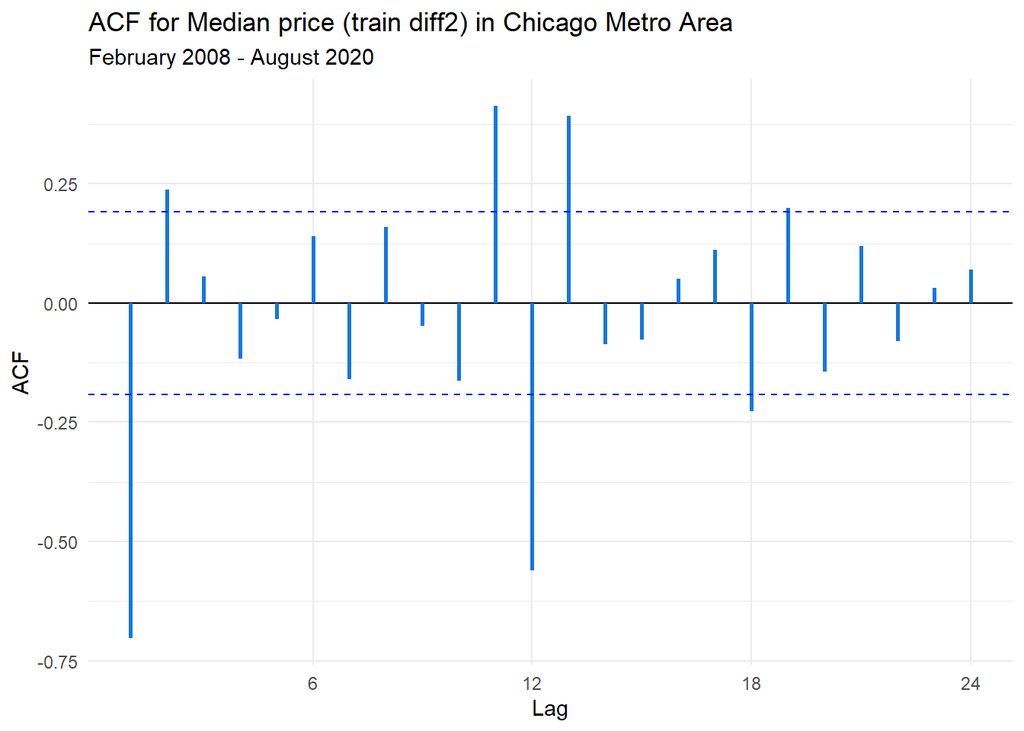

```r
# Check autocorrelation for Median price
ggAcf(Median_price_ts_train_diff2, color = "#1277e1", size = 1) +
         labs(title = "ACF for Median price (train diff2) in Chicago Metro Area", subtitle = "February 2008 - August 2020")
```

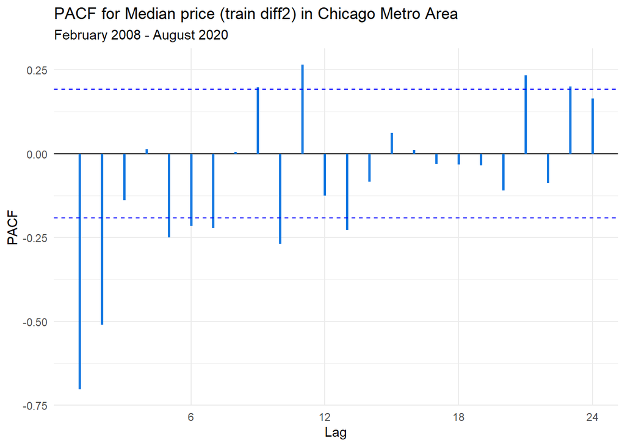

```r
# Check partial autocorrelation
ggPacf(Median_price_ts_train_diff2, color = "#1277e1", size = 1) +
         labs(title = "PACF for Median price (train diff2) in Chicago Metro Area", subtitle = "February 2008 - August 2020")
```

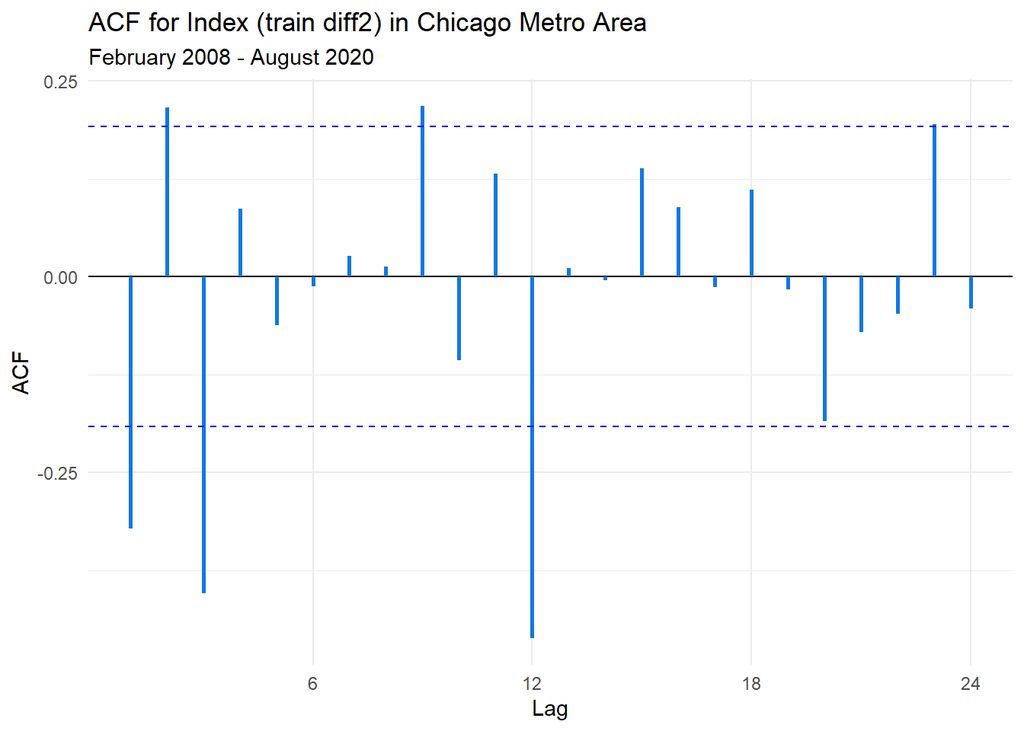

```r
# Check autocorrelation
ggAcf(Index_ts_train_diff2, color = "#1277e1", size = 1) +
         labs(title = "ACF for Index (train diff2) in Chicago Metro Area", subtitle = "February 2008 - August 2020")
```

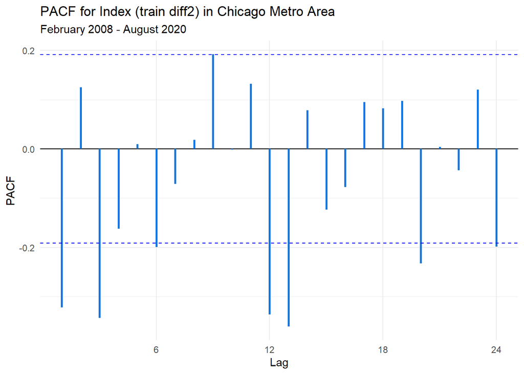

```r
# Check partial autocorrelation
ggPacf(Index_ts_train_diff2, color = "#1277e1", size = 1) +
         labs(title = "PACF for Index (train diff2) in Chicago Metro Area", subtitle = "February 2008 - August 2020")
```

#### Tests

```r
kpss.test(Median_price_ts_train_diff2)
```

```
##
##  KPSS Test for Level Stationarity
##
## data:  Median_price_ts_train_diff2
## KPSS Level = 0.049269, Truncation lag parameter = 4, p-value = 0.1
```

```r
kpss.test(Index_ts_train_diff2)
```

```
##
##  KPSS Test for Level Stationarity
##
## data:  Index_ts_train_diff2
## KPSS Level = 0.031233, Truncation lag parameter = 4, p-value = 0.1
```

```r
adf.test(Median_price_ts_train_diff2)
```

```
##
##  Augmented Dickey-Fuller Test
##
## data:  Median_price_ts_train_diff2
## Dickey-Fuller = -7.6873, Lag order = 4, p-value = 0.01
## alternative hypothesis: stationary
```

```r
adf.test(Index_ts_train_diff2)
```

```
##
##  Augmented Dickey-Fuller Test
##
## data:  Index_ts_train_diff2
## Dickey-Fuller = -6.6593, Lag order = 4, p-value = 0.01
## alternative hypothesis: stationary
```

Here both tests tell us that our data is stationary.

#### VAR select

```r
# Use VAR select
model1_diff2 <- VARselect(cbind(Median_price_ts_train_diff2, Index_ts_train_diff2))

# Print the model
model1_diff2
```

```
## $selection
## AIC(n)  HQ(n)  SC(n) FPE(n)
##     10      5      2     10
##
## $criteria
##                      1               2               3               4
## AIC(n)        19.61796        19.11678        19.04124        19.01984
## HQ(n)         19.68314        19.22541        19.19332        19.21537
## SC(n)         19.77926        19.38561        19.41761        19.50373
## FPE(n) 331123212.47982 200630015.72658 186097210.01380 182266119.71973
##                      5               6               7               8
## AIC(n)        18.94531        18.91281        18.86223        18.93410
## HQ(n)         19.18429        19.19525        19.18812        19.30343
## SC(n)         19.53673        19.61177        19.66872        19.84812
## FPE(n) 169336295.84342 164146567.04075 156343037.73581 168405821.86867
##                      9              10
## AIC(n)        18.87334        18.76730
## HQ(n)         19.28612        19.22353
## SC(n)         19.89489        19.89638
## FPE(n) 158976283.01240 143541919.02899
```

`VARselect` offers us to try model with p = 10.

#### Model

```r
# Var 10
varmodel10_diff2 <- VAR(cbind(Median_price_ts_train_diff2, Index_ts_train_diff2), p = 10, type = "both", season = 12)

# Pormonteau test
serial.test(varmodel10_diff2, lags.pt = 20, type = "PT.asymptotic")
```

```
##
##  Portmanteau Test (asymptotic)
##
## data:  Residuals of VAR object varmodel10_diff2
## Chi-squared = 121.06, df = 40, p-value = 0.0000000004399
```

```r
summary(varmodel10_diff2)
```

```
##
## VAR Estimation Results:
## =========================
## Endogenous variables: Median_price_ts_train_diff2, Index_ts_train_diff2
## Deterministic variables: both
## Sample size: 95
## Log Likelihood: -1117.315
## Roots of the characteristic polynomial:
## 0.9575 0.9575 0.9331 0.9331 0.9268 0.9268 0.9231 0.9231 0.9054 0.9054 0.8788 0.8788 0.8703 0.8703 0.8408 0.8408 0.755 0.755 0.6298 0.6298
## Call:
## VAR(y = cbind(Median_price_ts_train_diff2, Index_ts_train_diff2),
##     p = 10, type = "both", season = 12L)
##
##
## Estimation results for equation Median_price_ts_train_diff2:
## ============================================================
## Median_price_ts_train_diff2 = Median_price_ts_train_diff2.l1 + Index_ts_train_diff2.l1 + Median_price_ts_train_diff2.l2 + Index_ts_train_diff2.l2 + Median_price_ts_train_diff2.l3 + Index_ts_train_diff2.l3 + Median_price_ts_train_diff2.l4 + Index_ts_train_diff2.l4 + Median_price_ts_train_diff2.l5 …
##
##                                   Estimate Std. Error t value
## Median_price_ts_train_diff2.l1     -1.2423     0.1217 -10.211
## Index_ts_train_diff2.l1           448.6773   799.6598   0.561
## Median_price_ts_train_diff2.l2     -1.0317     0.1988  -5.189
## Index_ts_train_diff2.l2         -1501.1615   812.0509  -1.849
## Median_price_ts_train_diff2.l3     -0.7346     0.2345  -3.133
## Index_ts_train_diff2.l3          1422.6110   814.7607   1.746
## Median_price_ts_train_diff2.l4     -0.8494     0.2390  -3.554
## Index_ts_train_diff2.l4          -805.8231   877.1352  -0.919
## Median_price_ts_train_diff2.l5     -0.9567     0.2361  -4.052
## Index_ts_train_diff2.l5          -531.6822   879.2596  -0.605
## Median_price_ts_train_diff2.l6     -0.6775     0.2307  -2.937
## Index_ts_train_diff2.l6           311.9027   878.1541   0.355
## Median_price_ts_train_diff2.l7     -0.3949     0.2278  -1.734
## Index_ts_train_diff2.l7           900.1310   860.2349   1.046
## Median_price_ts_train_diff2.l8     -0.2187     0.2170  -1.008
## Index_ts_train_diff2.l8           269.3039   732.5422   0.368
## Median_price_ts_train_diff2.l9     -0.2850     0.1849  -1.541
## Index_ts_train_diff2.l9          1550.9141   718.3378   2.159
## Median_price_ts_train_diff2.l10    -0.3386     0.1105  -3.065
## Index_ts_train_diff2.l10          455.1697   723.4958   0.629
## const                             949.0297  2192.6795   0.433
```

[output cut: 97 more lines]

```
## Residual standard error: 1.362 on 62 degrees of freedom
## Multiple R-Squared: 0.4018,  Adjusted R-squared: 0.09303
## F-statistic: 1.301 on 32 and 62 DF,  p-value: 0.1855
##
##
##
## Covariance matrix of residuals:
##                             Median_price_ts_train_diff2 Index_ts_train_diff2
## Median_price_ts_train_diff2                    74431198             2434.885
## Index_ts_train_diff2                               2435                1.856
##
## Correlation matrix of residuals:
##                             Median_price_ts_train_diff2 Index_ts_train_diff2
## Median_price_ts_train_diff2                      1.0000               0.2071
## Index_ts_train_diff2                             0.2071               1.0000
```

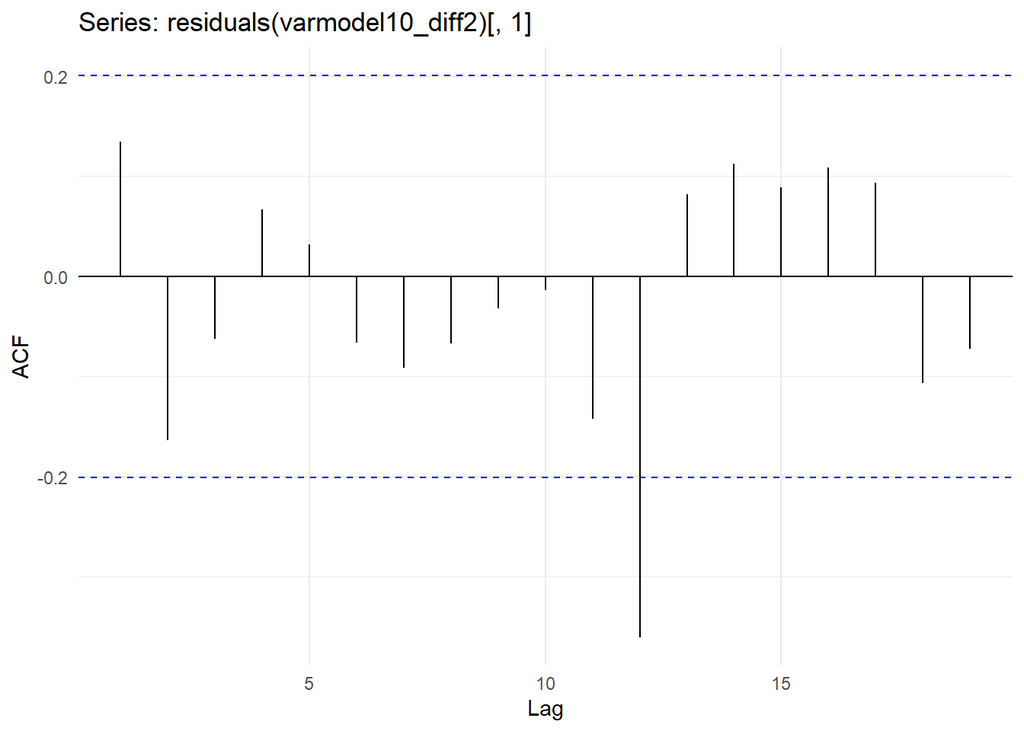

```r
# Check residuals for the model
ggAcf(residuals(varmodel10_diff2)[, 1])
```

#### Forecast

```r
# Create a forecast
varmodel10_diff2_forecast <- ts(predict(varmodel10_diff2, n.ahead = 12, ci = .95)$fcst$Median_price_ts_train[, 1], start = test_start, frequency = 12)
```

#### Evaluate the model

```r
# Analyze accuracy
accuracy(varmodel10_diff2_forecast, Median_price_ts_test_diff2)
```

```
##                ME     RMSE      MAE      MPE     MAPE       ACF1 Theil's U
## Test set 696.8191 9949.741 8706.368 158.9391 162.3552 -0.7547255  1.052893
```

```r
accuracy(varmodel10_diff2_forecast, Index_ts_test_diff2)
```

```
##                 ME     RMSE      MAE      MPE     MAPE       ACF1 Theil's U
## Test set -1125.998 6470.666 5255.775 49122.73 991827.1 -0.4488619  3381.592
```

We can see that our evaluation metrics look much worse.

### VAR with Diff1-2

#### 2st order differencing

Again, we need to difference data (2st order for seasonality and 1 order for trend)

```r
# Create new variables
Median_price_ts_diff12 <- diff(diff(Median_price_ts, differences = 1), lag = 12, differences = 2)
Index_ts_diff12 <- diff(diff(Index_ts, differences = 1), lag = 12, differences = 2)

# Check class
class(Median_price_ts_diff12)
```

```
## [1] "ts"
```

```r
class(Index_ts_diff12)
```

```
## [1] "ts"
```

```r
# Print
Median_price_ts_diff12
```

```
##         Jan    Feb    Mar    Apr    May    Jun    Jul    Aug    Sep    Oct
## 2010               -11000   4000   1500   3500   2900   3700  -8600   7700
## 2011 -13750   6000 -22500  11500 -11000  -7000  20300 -18500   4200 -13400
## 2012  10500  -8000  41000 -16000  14000   8000 -23000   7600  14400  -5300
## 2013  -8750      0 -21500   8500   1000  -2250  10250   8500 -13000  12900
## 2014  12000  -3000   1000 -10500  -5500  -8500  -6500   2500  -3500  -4300
## 2015 -10000   9000   3000   9000  -9000  -4750   5650 -16400  14000   7900
## 2016   2000  -6005  -3745    250   3750   4750    200   9300 -13500    500
## 2017   7500   3510  -2010  -8000  -1500  10000  -4600  -3200  10300 -11000
## 2018  -8875   1495  -4245    750   5750  -5850   1100   3600  -1600   1000
## 2019   3250   -500   4000   2000   4000  -6300   8300   2700  -6700   6000
## 2020  -3875  -7500  14500   6000 -20000   5900   2100  12000
##         Nov    Dec
## 2010 -15700   1750
## 2011  10400  -4500
## 2012   8300   5750
## 2013 -18400  -3000
## 2014   8300   3000
## 2015  -3400  -1000
## 2016   5000  -1500
## 2017  -3000   4875
## 2018   4500 -12250
## 2019  -4750   9625
## 2020
```

```r
Index_ts_diff12
```

```
##             Jan        Feb        Mar        Apr        May        Jun
## 2010                        1.0865100 -1.7455900  0.6500400 -5.9547500
## 2011 -1.8999400 -0.8513900 -2.0249600  0.3081500 -1.1351200  2.9683800
## 2012 -0.2210600  0.0035500  2.8469200  2.3453900  0.7311900 -0.0168200
## 2013  1.9757600  2.3685700  0.1982800 -3.3267500 -2.4368400  0.0046400
## 2014 -1.9449000 -1.5328604 -2.5616724 -1.6381452 -0.7501313 -3.7908345
## 2015  1.1375408 -0.8888615 -0.3933080  1.8199682  1.2726149  2.7443042
## 2016 -1.1898074  0.3981521  1.9406236  0.9948896  0.3894982  0.1312000
## 2017  0.4251928 -0.9783181 -1.6819325 -1.3503126  0.0768833 -0.0191815
## 2018  0.0675818  0.6567156  0.8455972  0.7165071 -0.0472132 -0.2875566
## 2019 -0.4140567 -0.8261509  0.2209460 -0.2217800  0.3850341  0.2346234
## 2020  0.5289302  1.7917237 -0.3374580  0.2118998 -1.2120778  1.1217624
##             Jul        Aug        Sep        Oct        Nov        Dec
## 2010 -4.0098400 -6.7237700 -2.0804000 -4.0184600 -1.7321900 -4.1077700
## 2011  2.7831300  4.5320700  1.5034600  0.0780200 -0.9694100 -0.1595400
## 2012 -1.8816300 -0.8420600 -0.1208900  3.6627900  2.1021500  1.3156900
## 2013  1.9633000  0.9220200  0.9175600 -2.4462200 -1.3627200 -1.8174300
## 2014 -2.5302469 -2.1001517 -1.9286168 -0.1457851 -0.6799324  1.9424272
## 2015  0.8466494  1.0124275  1.0121779  1.0421432  0.9976190 -1.7661605
## 2016  0.2214462  0.2205829 -0.4565895 -0.2280887  0.5094051  1.2170521
## 2017  0.7160065 -0.0738415  0.4871525 -1.1646980 -2.1597739 -0.8935855
## 2018 -0.1066316  0.2112422  0.1618413  0.3217792  0.8920157 -0.8062236
## 2019 -0.8151718 -1.6798819 -0.7552038  0.0283456  1.0560743  0.3907541
## 2020  2.3514227  4.3881108
```

```r
# Define again train and test
Median_price_ts_train_diff12 <- window(Median_price_ts_diff12, end = train_end)
Median_price_ts_test_diff12 <- window(Median_price_ts_diff12, start = test_start, end = test_end)
```

```r
# Define again train and test
Index_ts_train_diff12 <- window(Index_ts_diff12, end = train_end)
Index_ts_test_diff12 <- window(Index_ts_diff12, start = test_start, end = test_end)
```

```r
# Check correlation
cor(Median_price_ts_train_diff12, Index_ts_train_diff12)
```

```
## [1] 0.06106152
```

We can see that our correlation dropped slightly but remains positive.